RELIABILITY  
/VARIABLES=S2_R2 S1_R2 S1_R1 S2_R1  
/SCALE('ALL VARIABLES') ALL  
/MODEL=ALPHA  
/STATISTICS=CORR ANOVA  
/SUMMARY=CORR  
/ICC=MODEL(MIXED) TYPE(ABSOLUTE) CIN=95 TESTVAL=0.

# **Reliability**

NotesNotes, table, 0 levels of column headers and 2 levels of row headers, table with 3 columns and 15 rows

| Output Created |  | 15-APR-2019 23:52:05 |
| --- | --- | --- |
| Comments |  |  |
| Input | Data | Z:\Documents\GitHub\STISIM-Task-Analysis\SPSS Results\Driving mean speed.sav |
|  | Active Dataset | DataSet1 |
|  | Filter | <none> |
|  | Weight | <none> |
|  | Split File | <none> |
|  | N of Rows in Working Data File | 14 |
|  | Matrix Input |  |
| Missing Value Handling | Definition of Missing | User-defined missing values are treated as missing. |
|  | Cases Used | Statistics are based on all cases with valid data for all variables in the procedure. |
| Syntax |  | RELIABILITY /VARIABLES=S2_R2 S1_R2 S1_R1 S2_R1 /SCALE('ALL VARIABLES') ALL /MODEL=ALPHA /STATISTICS=CORR ANOVA /SUMMARY=CORR /ICC=MODEL(MIXED) TYPE(ABSOLUTE) CIN=95 TESTVAL=0. |
| Resources | Processor Time | 00:00:00.00 |
|  | Elapsed Time | 00:00:00.01 |

[DataSet1] Z:\Documents\GitHub\STISIM-Task-Analysis\SPSS Results\Driving mean speed.sav

# **Scale: ALL VARIABLES**

Case Processing SummaryCase Processing Summary, table, 1 levels of column headers and 2 levels of row headers, table with 4 columns and 6 rows

|  |  | N | % |
| --- | --- | --- | --- |
| Cases | Valid | 14 | 100.0 |
|  | Excluded<sup>a</sup> | 0 | .0 |
|  | Total | 14 | 100.0 |

a. Listwise deletion based on all variables in the procedure.

Reliability StatisticsReliability Statistics, table, 1 levels of column headers and 0 levels of row headers, table with 3 columns and 3 rows

| Cronbach's Alpha | Cronbach's Alpha Based on Standardized Items | N of Items |
| --- | --- | --- |
| .942 | .944 | 4 |

Inter-Item Correlation MatrixInter-Item Correlation Matrix, table, 1 levels of column headers and 1 levels of row headers, table with 5 columns and 6 rows

|  | S2_R2 | S1_R2 | S1_R1 | S2_R1 |
| --- | --- | --- | --- | --- |
| S2_R2 | 1.000 | .764 | .678 | .876 |
| S1_R2 | .764 | 1.000 | .910 | .857 |
| S1_R1 | .678 | .910 | 1.000 | .756 |
| S2_R1 | .876 | .857 | .756 | 1.000 |

Summary Item StatisticsSummary Item Statistics, table, 1 levels of column headers and 1 levels of row headers, table with 8 columns and 3 rows

|  | Mean | Minimum | Maximum | Range | Maximum / Minimum | Variance | N of Items |
| --- | --- | --- | --- | --- | --- | --- | --- |
| Inter-Item Correlations | .807 | .678 | .910 | .232 | 1.342 | .007 | 4 |

ANOVAANOVA, table, 1 levels of column headers and 2 levels of row headers, table with 7 columns and 8 rows

|  |  | Sum of Squares | df | Mean Square | F | Sig |
| --- | --- | --- | --- | --- | --- | --- |
| Between People |  | .291 | 13 | .022 |  |  |
| Within People | Between Items | .005 | 3 | .002 | 1.229 | .312 |
|  | Residual | .050 | 39 | .001 |  |  |
|  | Total | .055 | 42 | .001 |  |  |
| Total |  | .346 | 55 | .006 |  |  |

Grand Mean = .4880

Intraclass Correlation CoefficientIntraclass Correlation Coefficient, table, 2 levels of column headers and 1 levels of row headers, table with 8 columns and 9 rows

|  | Intraclass Correlation<sup>b</sup> | 95% Confidence Interval |  | F Test with True Value 0 |  |  |  |
| --- | --- | --- | --- | --- | --- | --- | --- |
|  |  | Lower Bound | Upper Bound | Value | df1 | df2 | Sig |
| Single Measures | .801<sup>a</sup> | .626 | .921 | 17.382 | 13 | 39 | .000 |
| Average Measures | .942<sup>c</sup> | .870 | .979 | 17.382 | 13 | 39 | .000 |

Two-way mixed effects model where people effects are random and measures effects are fixed.  
a. The estimator is the same, whether the interaction effect is present or not.  
b. Type A intraclass correlation coefficients using an absolute agreement definition.  
c. This estimate is computed assuming the interaction effect is absent, because it is not estimable otherwise.

CORRELATIONS  
/VARIABLES=S2_R1 S2_R2 S1_R1 S1_R2  
/PRINT=TWOTAIL NOSIG  
/MISSING=PAIRWISE.

# **Correlations**

NotesNotes, table, 0 levels of column headers and 2 levels of row headers, table with 3 columns and 14 rows

| Output Created |  | 15-APR-2019 23:52:05 |
| --- | --- | --- |
| Comments |  |  |
| Input | Data | Z:\Documents\GitHub\STISIM-Task-Analysis\SPSS Results\Driving mean speed.sav |
|  | Active Dataset | DataSet1 |
|  | Filter | <none> |
|  | Weight | <none> |
|  | Split File | <none> |
|  | N of Rows in Working Data File | 14 |
| Missing Value Handling | Definition of Missing | User-defined missing values are treated as missing. |
|  | Cases Used | Statistics for each pair of variables are based on all the cases with valid data for that pair. |
| Syntax |  | CORRELATIONS /VARIABLES=S2_R1 S2_R2 S1_R1 S1_R2 /PRINT=TWOTAIL NOSIG /MISSING=PAIRWISE. |
| Resources | Processor Time | 00:00:00.00 |
|  | Elapsed Time | 00:00:00.01 |

CorrelationsCorrelations, table, 1 levels of column headers and 2 levels of row headers, table with 6 columns and 15 rows

|  |  | S2_R1 | S2_R2 | S1_R1 | S1_R2 |
| --- | --- | --- | --- | --- | --- |
| S2_R1 | Pearson Correlation | 1 | .876** | .756** | .857** |
|  | Sig. (2-tailed) |  | .000 | .002 | .000 |
|  | N | 14 | 14 | 14 | 14 |
| S2_R2 | Pearson Correlation | .876** | 1 | .678** | .764** |
|  | Sig. (2-tailed) | .000 |  | .008 | .001 |
|  | N | 14 | 14 | 14 | 14 |
| S1_R1 | Pearson Correlation | .756** | .678** | 1 | .910** |
|  | Sig. (2-tailed) | .002 | .008 |  | .000 |
|  | N | 14 | 14 | 14 | 14 |
| S1_R2 | Pearson Correlation | .857** | .764** | .910** | 1 |
|  | Sig. (2-tailed) | .000 | .001 | .000 |  |
|  | N | 14 | 14 | 14 | 14 |

**. Correlation is significant at the 0.01 level (2-tailed).

RELIABILITY  
/VARIABLES=S1_R1 S1_R2  
/SCALE('ALL VARIABLES') ALL  
/MODEL=ALPHA  
/STATISTICS=CORR ANOVA  
/ICC=MODEL(MIXED) TYPE(ABSOLUTE) CIN=95 TESTVAL=0.

# **Reliability**

NotesNotes, table, 0 levels of column headers and 2 levels of row headers, table with 3 columns and 15 rows

| Output Created |  | 15-APR-2019 23:52:05 |
| --- | --- | --- |
| Comments |  |  |
| Input | Data | Z:\Documents\GitHub\STISIM-Task-Analysis\SPSS Results\Driving mean speed.sav |
|  | Active Dataset | DataSet1 |
|  | Filter | <none> |
|  | Weight | <none> |
|  | Split File | <none> |
|  | N of Rows in Working Data File | 14 |
|  | Matrix Input |  |
| Missing Value Handling | Definition of Missing | User-defined missing values are treated as missing. |
|  | Cases Used | Statistics are based on all cases with valid data for all variables in the procedure. |
| Syntax |  | RELIABILITY /VARIABLES=S1_R1 S1_R2 /SCALE('ALL VARIABLES') ALL /MODEL=ALPHA /STATISTICS=CORR ANOVA /ICC=MODEL(MIXED) TYPE(ABSOLUTE) CIN=95 TESTVAL=0. |
| Resources | Processor Time | 00:00:00.02 |
|  | Elapsed Time | 00:00:00.00 |

# **Scale: ALL VARIABLES**

Case Processing SummaryCase Processing Summary, table, 1 levels of column headers and 2 levels of row headers, table with 4 columns and 6 rows

|  |  | N | % |
| --- | --- | --- | --- |
| Cases | Valid | 14 | 100.0 |
|  | Excluded<sup>a</sup> | 0 | .0 |
|  | Total | 14 | 100.0 |

a. Listwise deletion based on all variables in the procedure.

Reliability StatisticsReliability Statistics, table, 1 levels of column headers and 0 levels of row headers, table with 3 columns and 3 rows

| Cronbach's Alpha | Cronbach's Alpha Based on Standardized Items | N of Items |
| --- | --- | --- |
| .952 | .953 | 2 |

Inter-Item Correlation MatrixInter-Item Correlation Matrix, table, 1 levels of column headers and 1 levels of row headers, table with 3 columns and 4 rows

|  | S1_R1 | S1_R2 |
| --- | --- | --- |
| S1_R1 | 1.000 | .910 |
| S1_R2 | .910 | 1.000 |

ANOVAANOVA, table, 1 levels of column headers and 2 levels of row headers, table with 7 columns and 8 rows

|  |  | Sum of Squares | df | Mean Square | F | Sig |
| --- | --- | --- | --- | --- | --- | --- |
| Between People |  | .156 | 13 | .012 |  |  |
| Within People | Between Items | .001 | 1 | .001 | .906 | .359 |
|  | Residual | .008 | 13 | .001 |  |  |
|  | Total | .008 | 14 | .001 |  |  |
| Total |  | .164 | 27 | .006 |  |  |

Grand Mean = .4917

Intraclass Correlation CoefficientIntraclass Correlation Coefficient, table, 2 levels of column headers and 1 levels of row headers, table with 8 columns and 9 rows

|  | Intraclass Correlation<sup>b</sup> | 95% Confidence Interval |  | F Test with True Value 0 |  |  |  |
| --- | --- | --- | --- | --- | --- | --- | --- |
|  |  | Lower Bound | Upper Bound | Value | df1 | df2 | Sig |
| Single Measures | .909<sup>a</sup> | .747 | .969 | 20.731 | 13 | 13 | .000 |
| Average Measures | .952<sup>c</sup> | .855 | .984 | 20.731 | 13 | 13 | .000 |

Two-way mixed effects model where people effects are random and measures effects are fixed.  
a. The estimator is the same, whether the interaction effect is present or not.  
b. Type A intraclass correlation coefficients using an absolute agreement definition.  
c. This estimate is computed assuming the interaction effect is absent, because it is not estimable otherwise.

CORRELATIONS  
/VARIABLES=S1_R1 S1_R2  
/PRINT=TWOTAIL NOSIG  
/MISSING=PAIRWISE.

# **Correlations**

NotesNotes, table, 0 levels of column headers and 2 levels of row headers, table with 3 columns and 14 rows

| Output Created |  | 15-APR-2019 23:52:05 |
| --- | --- | --- |
| Comments |  |  |
| Input | Data | Z:\Documents\GitHub\STISIM-Task-Analysis\SPSS Results\Driving mean speed.sav |
|  | Active Dataset | DataSet1 |
|  | Filter | <none> |
|  | Weight | <none> |
|  | Split File | <none> |
|  | N of Rows in Working Data File | 14 |
| Missing Value Handling | Definition of Missing | User-defined missing values are treated as missing. |
|  | Cases Used | Statistics for each pair of variables are based on all the cases with valid data for that pair. |
| Syntax |  | CORRELATIONS /VARIABLES=S1_R1 S1_R2 /PRINT=TWOTAIL NOSIG /MISSING=PAIRWISE. |
| Resources | Processor Time | 00:00:00.00 |
|  | Elapsed Time | 00:00:00.00 |

CorrelationsCorrelations, table, 1 levels of column headers and 2 levels of row headers, table with 4 columns and 9 rows

|  |  | S1_R1 | S1_R2 |
| --- | --- | --- | --- |
| S1_R1 | Pearson Correlation | 1 | .910** |
|  | Sig. (2-tailed) |  | .000 |
|  | N | 14 | 14 |
| S1_R2 | Pearson Correlation | .910** | 1 |
|  | Sig. (2-tailed) | .000 |  |
|  | N | 14 | 14 |

**. Correlation is significant at the 0.01 level (2-tailed).

RELIABILITY  
/VARIABLES=S2_R1 S2_R2  
/SCALE('ALL VARIABLES') ALL  
/MODEL=ALPHA  
/STATISTICS=CORR ANOVA  
/ICC=MODEL(MIXED) TYPE(ABSOLUTE) CIN=95 TESTVAL=0.

# **Reliability**

NotesNotes, table, 0 levels of column headers and 2 levels of row headers, table with 3 columns and 15 rows

| Output Created |  | 15-APR-2019 23:52:05 |
| --- | --- | --- |
| Comments |  |  |
| Input | Data | Z:\Documents\GitHub\STISIM-Task-Analysis\SPSS Results\Driving mean speed.sav |
|  | Active Dataset | DataSet1 |
|  | Filter | <none> |
|  | Weight | <none> |
|  | Split File | <none> |
|  | N of Rows in Working Data File | 14 |
|  | Matrix Input |  |
| Missing Value Handling | Definition of Missing | User-defined missing values are treated as missing. |
|  | Cases Used | Statistics are based on all cases with valid data for all variables in the procedure. |
| Syntax |  | RELIABILITY /VARIABLES=S2_R1 S2_R2 /SCALE('ALL VARIABLES') ALL /MODEL=ALPHA /STATISTICS=CORR ANOVA /ICC=MODEL(MIXED) TYPE(ABSOLUTE) CIN=95 TESTVAL=0. |
| Resources | Processor Time | 00:00:00.00 |
|  | Elapsed Time | 00:00:00.00 |

# **Scale: ALL VARIABLES**

Case Processing SummaryCase Processing Summary, table, 1 levels of column headers and 2 levels of row headers, table with 4 columns and 6 rows

|  |  | N | % |
| --- | --- | --- | --- |
| Cases | Valid | 14 | 100.0 |
|  | Excluded<sup>a</sup> | 0 | .0 |
|  | Total | 14 | 100.0 |

a. Listwise deletion based on all variables in the procedure.

Reliability StatisticsReliability Statistics, table, 1 levels of column headers and 0 levels of row headers, table with 3 columns and 3 rows

| Cronbach's Alpha | Cronbach's Alpha Based on Standardized Items | N of Items |
| --- | --- | --- |
| .931 | .934 | 2 |

Inter-Item Correlation MatrixInter-Item Correlation Matrix, table, 1 levels of column headers and 1 levels of row headers, table with 3 columns and 4 rows

|  | S2_R1 | S2_R2 |
| --- | --- | --- |
| S2_R1 | 1.000 | .876 |
| S2_R2 | .876 | 1.000 |

ANOVAANOVA, table, 1 levels of column headers and 2 levels of row headers, table with 7 columns and 8 rows

|  |  | Sum of Squares | df | Mean Square | F | Sig |
| --- | --- | --- | --- | --- | --- | --- |
| Between People |  | .167 | 13 | .013 |  |  |
| Within People | Between Items | .003 | 1 | .003 | 3.949 | .068 |
|  | Residual | .011 | 13 | .001 |  |  |
|  | Total | .015 | 14 | .001 |  |  |
| Total |  | .182 | 27 | .007 |  |  |

Grand Mean = .4844

Intraclass Correlation CoefficientIntraclass Correlation Coefficient, table, 2 levels of column headers and 1 levels of row headers, table with 8 columns and 9 rows

|  | Intraclass Correlation<sup>b</sup> | 95% Confidence Interval |  | F Test with True Value 0 |  |  |  |
| --- | --- | --- | --- | --- | --- | --- | --- |
|  |  | Lower Bound | Upper Bound | Value | df1 | df2 | Sig |
| Single Measures | .849<sup>a</sup> | .570 | .950 | 14.592 | 13 | 13 | .000 |
| Average Measures | .918<sup>c</sup> | .727 | .974 | 14.592 | 13 | 13 | .000 |

Two-way mixed effects model where people effects are random and measures effects are fixed.  
a. The estimator is the same, whether the interaction effect is present or not.  
b. Type A intraclass correlation coefficients using an absolute agreement definition.  
c. This estimate is computed assuming the interaction effect is absent, because it is not estimable otherwise.

CORRELATIONS  
/VARIABLES=S2_R1 S2_R2  
/PRINT=TWOTAIL NOSIG  
/MISSING=PAIRWISE.

# **Correlations**

NotesNotes, table, 0 levels of column headers and 2 levels of row headers, table with 3 columns and 14 rows

| Output Created |  | 15-APR-2019 23:52:05 |
| --- | --- | --- |
| Comments |  |  |
| Input | Data | Z:\Documents\GitHub\STISIM-Task-Analysis\SPSS Results\Driving mean speed.sav |
|  | Active Dataset | DataSet1 |
|  | Filter | <none> |
|  | Weight | <none> |
|  | Split File | <none> |
|  | N of Rows in Working Data File | 14 |
| Missing Value Handling | Definition of Missing | User-defined missing values are treated as missing. |
|  | Cases Used | Statistics for each pair of variables are based on all the cases with valid data for that pair. |
| Syntax |  | CORRELATIONS /VARIABLES=S2_R1 S2_R2 /PRINT=TWOTAIL NOSIG /MISSING=PAIRWISE. |
| Resources | Processor Time | 00:00:00.00 |
|  | Elapsed Time | 00:00:00.01 |

CorrelationsCorrelations, table, 1 levels of column headers and 2 levels of row headers, table with 4 columns and 9 rows

|  |  | S2_R1 | S2_R2 |
| --- | --- | --- | --- |
| S2_R1 | Pearson Correlation | 1 | .876** |
|  | Sig. (2-tailed) |  | .000 |
|  | N | 14 | 14 |
| S2_R2 | Pearson Correlation | .876** | 1 |
|  | Sig. (2-tailed) | .000 |  |
|  | N | 14 | 14 |

**. Correlation is significant at the 0.01 level (2-tailed).

RELIABILITY  
/VARIABLES=S2_R2 S1_R2  
/SCALE('ALL VARIABLES') ALL  
/MODEL=ALPHA  
/STATISTICS=CORR ANOVA  
/SUMMARY=CORR  
/ICC=MODEL(MIXED) TYPE(ABSOLUTE) CIN=95 TESTVAL=0.

# **Reliability**

NotesNotes, table, 0 levels of column headers and 2 levels of row headers, table with 3 columns and 15 rows

| Output Created |  | 15-APR-2019 23:52:05 |
| --- | --- | --- |
| Comments |  |  |
| Input | Data | Z:\Documents\GitHub\STISIM-Task-Analysis\SPSS Results\Driving mean speed.sav |
|  | Active Dataset | DataSet1 |
|  | Filter | <none> |
|  | Weight | <none> |
|  | Split File | <none> |
|  | N of Rows in Working Data File | 14 |
|  | Matrix Input |  |
| Missing Value Handling | Definition of Missing | User-defined missing values are treated as missing. |
|  | Cases Used | Statistics are based on all cases with valid data for all variables in the procedure. |
| Syntax |  | RELIABILITY /VARIABLES=S2_R2 S1_R2 /SCALE('ALL VARIABLES') ALL /MODEL=ALPHA /STATISTICS=CORR ANOVA /SUMMARY=CORR /ICC=MODEL(MIXED) TYPE(ABSOLUTE) CIN=95 TESTVAL=0. |
| Resources | Processor Time | 00:00:00.00 |
|  | Elapsed Time | 00:00:00.00 |

# **Scale: ALL VARIABLES**

Case Processing SummaryCase Processing Summary, table, 1 levels of column headers and 2 levels of row headers, table with 4 columns and 6 rows

|  |  | N | % |
| --- | --- | --- | --- |
| Cases | Valid | 14 | 100.0 |
|  | Excluded<sup>a</sup> | 0 | .0 |
|  | Total | 14 | 100.0 |

a. Listwise deletion based on all variables in the procedure.

Reliability StatisticsReliability Statistics, table, 1 levels of column headers and 0 levels of row headers, table with 3 columns and 3 rows

| Cronbach's Alpha | Cronbach's Alpha Based on Standardized Items | N of Items |
| --- | --- | --- |
| .866 | .866 | 2 |

Inter-Item Correlation MatrixInter-Item Correlation Matrix, table, 1 levels of column headers and 1 levels of row headers, table with 3 columns and 4 rows

|  | S2_R2 | S1_R2 |
| --- | --- | --- |
| S2_R2 | 1.000 | .764 |
| S1_R2 | .764 | 1.000 |

Summary Item StatisticsSummary Item Statistics, table, 1 levels of column headers and 1 levels of row headers, table with 8 columns and 3 rows

|  | Mean | Minimum | Maximum | Range | Maximum / Minimum | Variance | N of Items |
| --- | --- | --- | --- | --- | --- | --- | --- |
| Inter-Item Correlations | .764 | .764 | .764 | .000 | 1.000 | .000 | 2 |

ANOVAANOVA, table, 1 levels of column headers and 2 levels of row headers, table with 7 columns and 8 rows

|  |  | Sum of Squares | df | Mean Square | F | Sig |
| --- | --- | --- | --- | --- | --- | --- |
| Between People |  | .164 | 13 | .013 |  |  |
| Within People | Between Items | .000 | 1 | .000 | .001 | .975 |
|  | Residual | .022 | 13 | .002 |  |  |
|  | Total | .022 | 14 | .002 |  |  |
| Total |  | .186 | 27 | .007 |  |  |

Grand Mean = .4957

Intraclass Correlation CoefficientIntraclass Correlation Coefficient, table, 2 levels of column headers and 1 levels of row headers, table with 8 columns and 9 rows

|  | Intraclass Correlation<sup>b</sup> | 95% Confidence Interval |  | F Test with True Value 0 |  |  |  |
| --- | --- | --- | --- | --- | --- | --- | --- |
|  |  | Lower Bound | Upper Bound | Value | df1 | df2 | Sig |
| Single Measures | .776<sup>a</sup> | .428 | .923 | 7.436 | 13 | 13 | .000 |
| Average Measures | .874<sup>c</sup> | .599 | .960 | 7.436 | 13 | 13 | .000 |

Two-way mixed effects model where people effects are random and measures effects are fixed.  
a. The estimator is the same, whether the interaction effect is present or not.  
b. Type A intraclass correlation coefficients using an absolute agreement definition.  
c. This estimate is computed assuming the interaction effect is absent, because it is not estimable otherwise.

CORRELATIONS  
/VARIABLES=S2_R2 S1_R2  
/PRINT=TWOTAIL NOSIG  
/MISSING=PAIRWISE.

# **Correlations**

NotesNotes, table, 0 levels of column headers and 2 levels of row headers, table with 3 columns and 14 rows

| Output Created |  | 15-APR-2019 23:52:05 |
| --- | --- | --- |
| Comments |  |  |
| Input | Data | Z:\Documents\GitHub\STISIM-Task-Analysis\SPSS Results\Driving mean speed.sav |
|  | Active Dataset | DataSet1 |
|  | Filter | <none> |
|  | Weight | <none> |
|  | Split File | <none> |
|  | N of Rows in Working Data File | 14 |
| Missing Value Handling | Definition of Missing | User-defined missing values are treated as missing. |
|  | Cases Used | Statistics for each pair of variables are based on all the cases with valid data for that pair. |
| Syntax |  | CORRELATIONS /VARIABLES=S2_R2 S1_R2 /PRINT=TWOTAIL NOSIG /MISSING=PAIRWISE. |
| Resources | Processor Time | 00:00:00.05 |
|  | Elapsed Time | 00:00:00.01 |

CorrelationsCorrelations, table, 1 levels of column headers and 2 levels of row headers, table with 4 columns and 9 rows

|  |  | S2_R2 | S1_R2 |
| --- | --- | --- | --- |
| S2_R2 | Pearson Correlation | 1 | .764** |
|  | Sig. (2-tailed) |  | .001 |
|  | N | 14 | 14 |
| S1_R2 | Pearson Correlation | .764** | 1 |
|  | Sig. (2-tailed) | .001 |  |
|  | N | 14 | 14 |

**. Correlation is significant at the 0.01 level (2-tailed).

* Encoding: UTF-8.  
EXAMINE VARIABLES=S1_R1 S1_R2 S2_R1 S2_R2  
/PLOT BOXPLOT NPPLOT  
/COMPARE GROUPS  
/STATISTICS NONE  
/CINTERVAL 95  
/MISSING LISTWISE  
/NOTOTAL.

# **Explore**

NotesNotes, table, 0 levels of column headers and 2 levels of row headers, table with 3 columns and 14 rows

| Output Created |  | 15-APR-2019 23:52:32 |
| --- | --- | --- |
| Comments |  |  |
| Input | Data | Z:\Documents\GitHub\STISIM-Task-Analysis\SPSS Results\Driving mean speed.sav |
|  | Active Dataset | DataSet1 |
|  | Filter | <none> |
|  | Weight | <none> |
|  | Split File | <none> |
|  | N of Rows in Working Data File | 14 |
| Missing Value Handling | Definition of Missing | User-defined missing values for dependent variables are treated as missing. |
|  | Cases Used | Statistics are based on cases with no missing values for any dependent variable or factor used. |
| Syntax |  | EXAMINE VARIABLES=S1_R1 S1_R2 S2_R1 S2_R2 /PLOT BOXPLOT NPPLOT /COMPARE GROUPS /STATISTICS NONE /CINTERVAL 95 /MISSING LISTWISE /NOTOTAL. |
| Resources | Processor Time | 00:00:02.44 |
|  | Elapsed Time | 00:00:02.22 |

Case Processing SummaryCase Processing Summary, table, 3 levels of column headers and 1 levels of row headers, table with 7 columns and 8 rows

|  | Cases |  |  |  |  |  |
| --- | --- | --- | --- | --- | --- | --- |
|  | Valid |  | Missing |  | Total |  |
|  | N | Percent | N | Percent | N | Percent |
| S1_R1 | 14 | 100.0% | 0 | 0.0% | 14 | 100.0% |
| S1_R2 | 14 | 100.0% | 0 | 0.0% | 14 | 100.0% |
| S2_R1 | 14 | 100.0% | 0 | 0.0% | 14 | 100.0% |
| S2_R2 | 14 | 100.0% | 0 | 0.0% | 14 | 100.0% |

Tests of NormalityTests of Normality, table, 2 levels of column headers and 1 levels of row headers, table with 7 columns and 9 rows

|  | Kolmogorov-Smirnov<sup>a</sup> |  |  | Shapiro-Wilk |  |  |
| --- | --- | --- | --- | --- | --- | --- |
|  | Statistic | df | Sig. | Statistic | df | Sig. |
| S1_R1 | .189 | 14 | .187 | .937 | 14 | .382 |
| S1_R2 | .128 | 14 | .200* | .929 | 14 | .297 |
| S2_R1 | .205 | 14 | .115 | .908 | 14 | .148 |
| S2_R2 | .183 | 14 | .200* | .919 | 14 | .215 |

*. This is a lower bound of the true significance.  
a. Lilliefors Significance Correction

# **S1_R1**

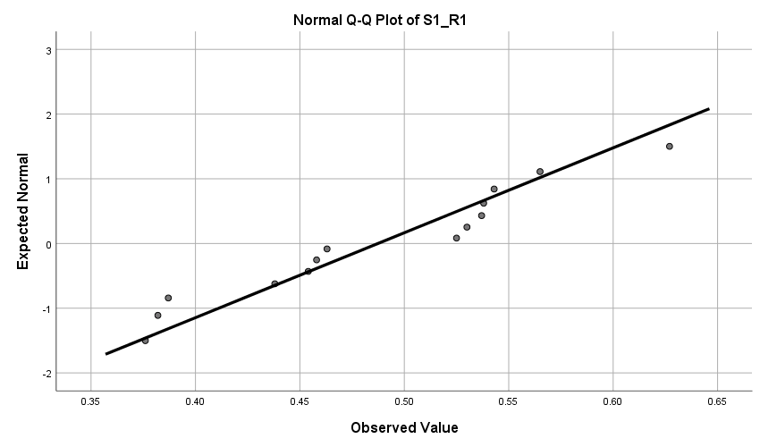

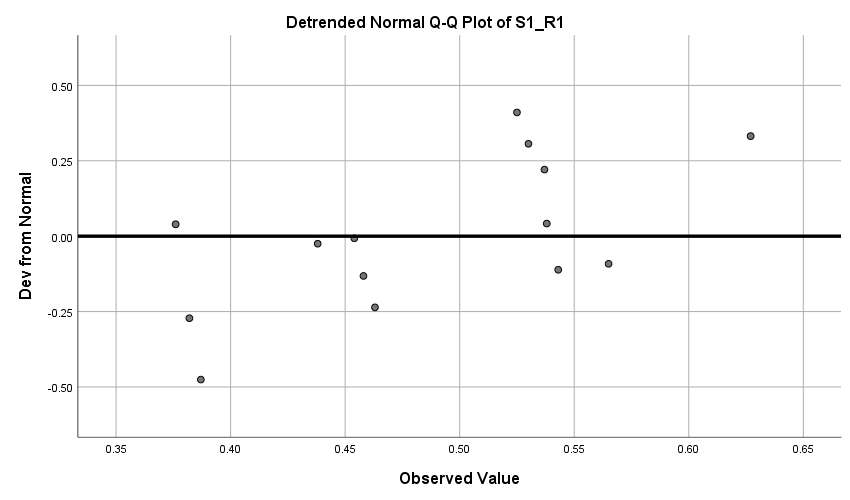

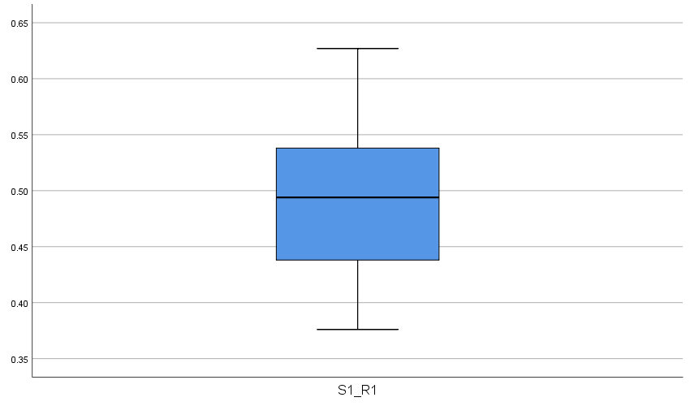

# **S1_R2**

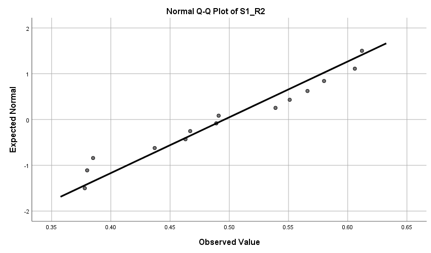

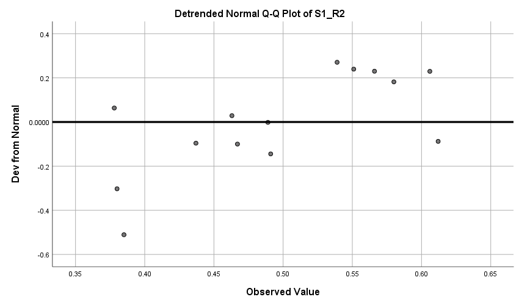

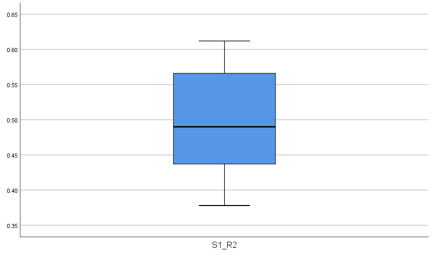

# **S2_R1**

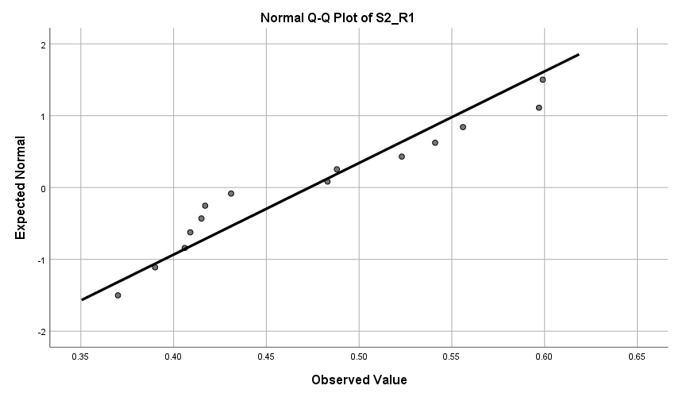

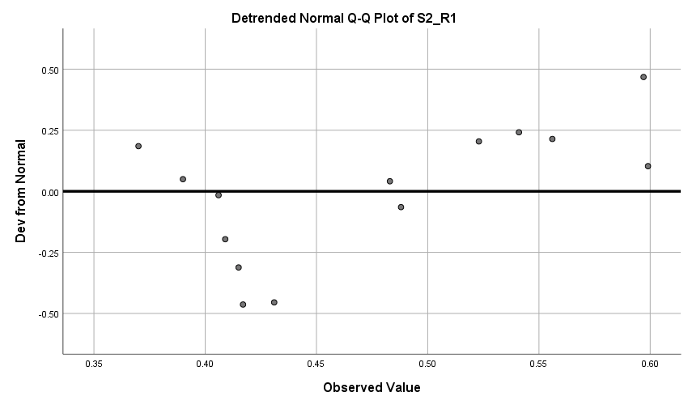

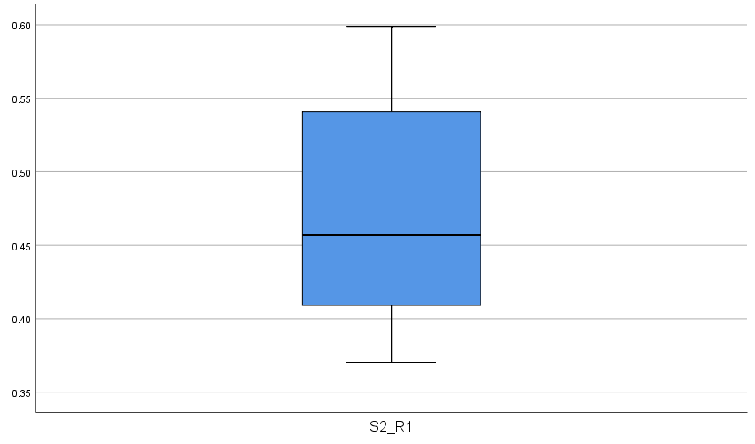

# **S2_R2**

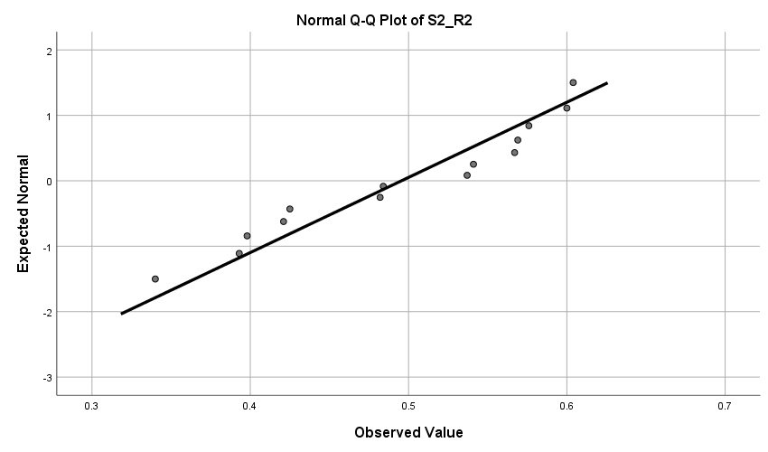

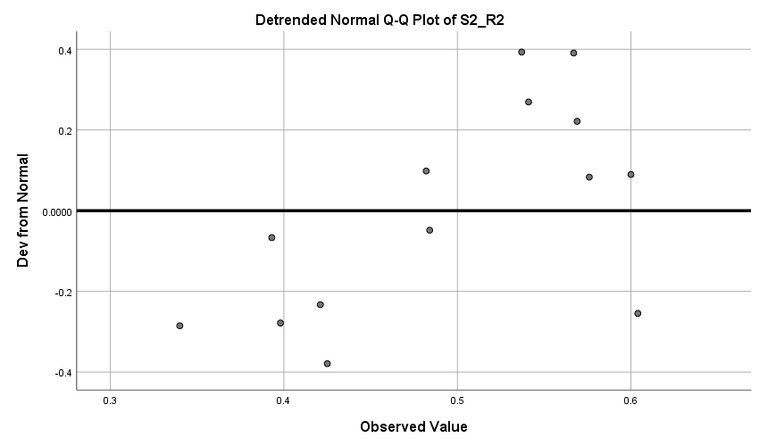

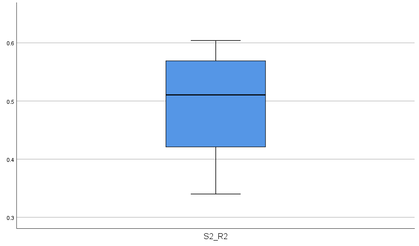

T-TEST PAIRS=S1_R1 S2_R1 S1_R2 WITH S1_R2 S2_R2 S2_R2 (PAIRED)  
/CRITERIA=CI(.9500)  
/MISSING=ANALYSIS.

# **T-Test**

NotesNotes, table, 0 levels of column headers and 2 levels of row headers, table with 3 columns and 14 rows

| Output Created |  | 15-APR-2019 23:52:34 |
| --- | --- | --- |
| Comments |  |  |
| Input | Data | Z:\Documents\GitHub\STISIM-Task-Analysis\SPSS Results\Driving mean speed.sav |
|  | Active Dataset | DataSet1 |
|  | Filter | <none> |
|  | Weight | <none> |
|  | Split File | <none> |
|  | N of Rows in Working Data File | 14 |
| Missing Value Handling | Definition of Missing | User defined missing values are treated as missing. |
|  | Cases Used | Statistics for each analysis are based on the cases with no missing or out-of-range data for any variable in the analysis. |
| Syntax |  | T-TEST PAIRS=S1_R1 S2_R1 S1_R2 WITH S1_R2 S2_R2 S2_R2 (PAIRED) /CRITERIA=CI(.9500) /MISSING=ANALYSIS. |
| Resources | Processor Time | 00:00:00.00 |
|  | Elapsed Time | 00:00:00.00 |

Paired Samples StatisticsPaired Samples Statistics, table, 1 levels of column headers and 2 levels of row headers, table with 6 columns and 8 rows

|  |  | Mean | N | Std. Deviation | Std. Error Mean |
| --- | --- | --- | --- | --- | --- |
| Pair 1 | S1_R1 | .4874 | 14 | .07619 | .02036 |
|  | S1_R2 | .4960 | 14 | .08208 | .02194 |
| Pair 2 | S2_R1 | .4732 | 14 | .07842 | .02096 |
|  | S2_R2 | .4955 | 14 | .08705 | .02326 |
| Pair 3 | S1_R2 | .4960 | 14 | .08208 | .02194 |
|  | S2_R2 | .4955 | 14 | .08705 | .02326 |

Paired Samples CorrelationsPaired Samples Correlations, table, 1 levels of column headers and 2 levels of row headers, table with 5 columns and 5 rows

|  |  | N | Correlation | Sig. |
| --- | --- | --- | --- | --- |
| Pair 1 | S1_R1 & S1_R2 | 14 | .910 | .000 |
| Pair 2 | S2_R1 & S2_R2 | 14 | .876 | .000 |
| Pair 3 | S1_R2 & S2_R2 | 14 | .764 | .001 |

Paired Samples TestPaired Samples Test, table, 3 levels of column headers and 2 levels of row headers, table with 10 columns and 7 rows

[output not shown]

COMPUTE logS1_R1=LG10(S1_R1).  
EXECUTE.  
COMPUTE logS1_R2=LG10(S1_R2).  
EXECUTE.  
COMPUTE logS2_R1=LG10(S2_R1).  
EXECUTE.  
COMPUTE logS2_R2=LG10(S2_R2).  
EXECUTE.  
EXAMINE VARIABLES=logS1_R1 logS1_R2 logS2_R1 logS2_R2  
/PLOT NPPLOT  
/STATISTICS NONE  
/CINTERVAL 95  
/MISSING LISTWISE  
/NOTOTAL.

# **Explore**

NotesNotes, table, 0 levels of column headers and 2 levels of row headers, table with 3 columns and 14 rows

| Output Created |  | 15-APR-2019 23:52:35 |
| --- | --- | --- |
| Comments |  |  |
| Input | Data | Z:\Documents\GitHub\STISIM-Task-Analysis\SPSS Results\Driving mean speed.sav |
|  | Active Dataset | DataSet1 |
|  | Filter | <none> |
|  | Weight | <none> |
|  | Split File | <none> |
|  | N of Rows in Working Data File | 14 |
| Missing Value Handling | Definition of Missing | User-defined missing values for dependent variables are treated as missing. |
|  | Cases Used | Statistics are based on cases with no missing values for any dependent variable or factor used. |
| Syntax |  | EXAMINE VARIABLES=logS1_R1 logS1_R2 logS2_R1 logS2_R2 /PLOT NPPLOT /STATISTICS NONE /CINTERVAL 95 /MISSING LISTWISE /NOTOTAL. |
| Resources | Processor Time | 00:00:01.51 |
|  | Elapsed Time | 00:00:01.44 |

Case Processing SummaryCase Processing Summary, table, 3 levels of column headers and 1 levels of row headers, table with 7 columns and 8 rows

|  | Cases |  |  |  |  |  |
| --- | --- | --- | --- | --- | --- | --- |
|  | Valid |  | Missing |  | Total |  |
|  | N | Percent | N | Percent | N | Percent |
| logS1_R1 | 14 | 100.0% | 0 | 0.0% | 14 | 100.0% |
| logS1_R2 | 14 | 100.0% | 0 | 0.0% | 14 | 100.0% |
| logS2_R1 | 14 | 100.0% | 0 | 0.0% | 14 | 100.0% |
| logS2_R2 | 14 | 100.0% | 0 | 0.0% | 14 | 100.0% |

Tests of NormalityTests of Normality, table, 2 levels of column headers and 1 levels of row headers, table with 7 columns and 9 rows

|  | Kolmogorov-Smirnov<sup>a</sup> |  |  | Shapiro-Wilk |  |  |
| --- | --- | --- | --- | --- | --- | --- |
|  | Statistic | df | Sig. | Statistic | df | Sig. |
| logS1_R1 | .205 | 14 | .112 | .928 | 14 | .290 |
| logS1_R2 | .143 | 14 | .200* | .919 | 14 | .212 |
| logS2_R1 | .190 | 14 | .185 | .919 | 14 | .211 |
| logS2_R2 | .198 | 14 | .141 | .910 | 14 | .157 |

*. This is a lower bound of the true significance.  
a. Lilliefors Significance Correction

# **logS1_R1**

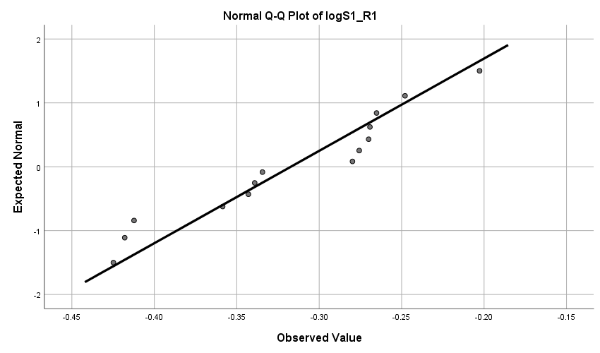

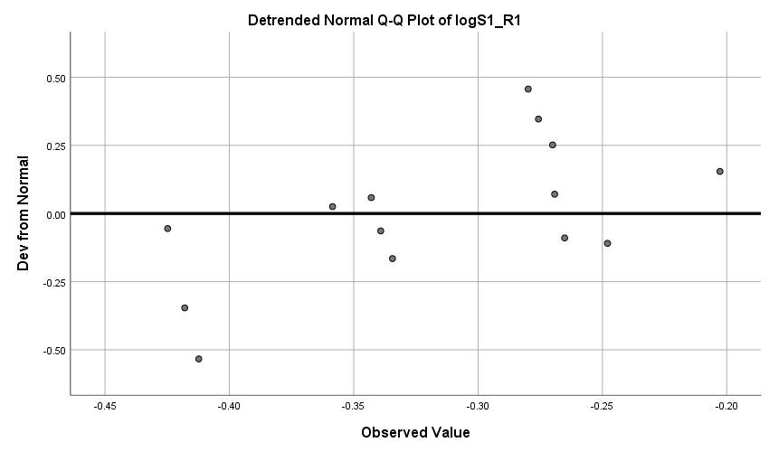

# **logS1_R2**

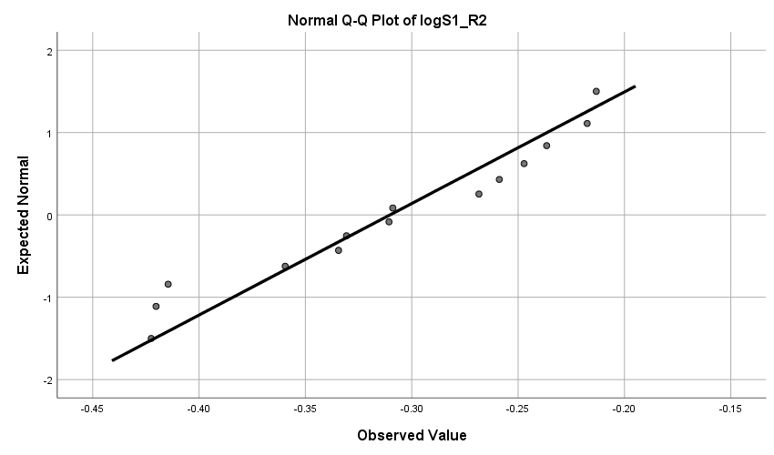

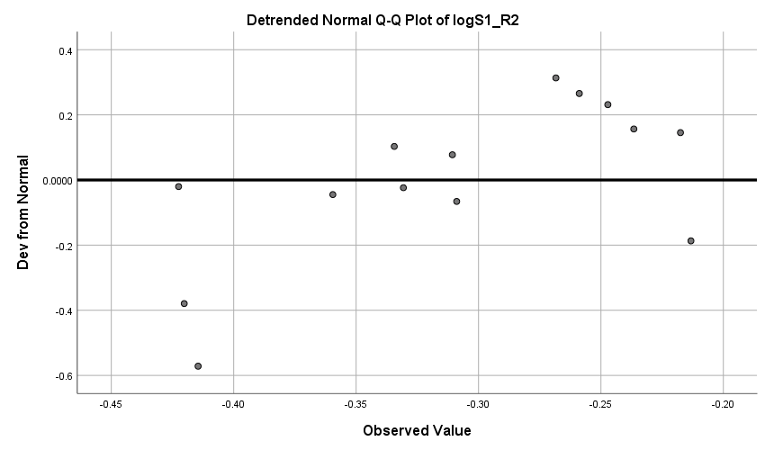

# **logS2_R1**

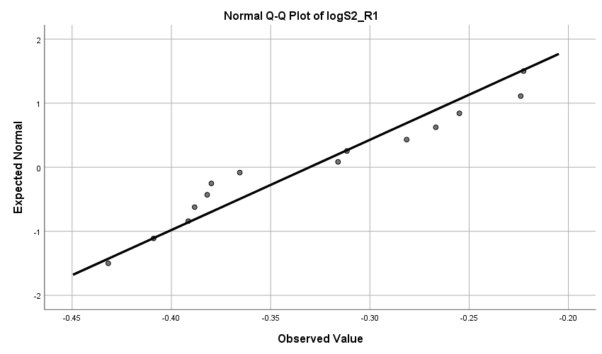

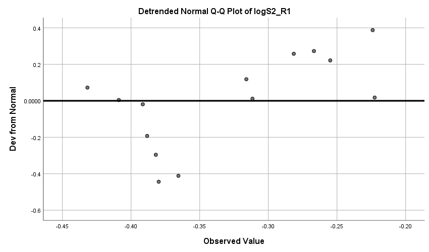

# **logS2_R2**

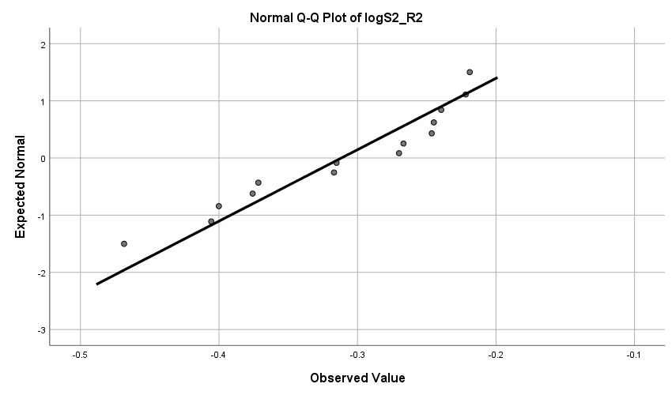

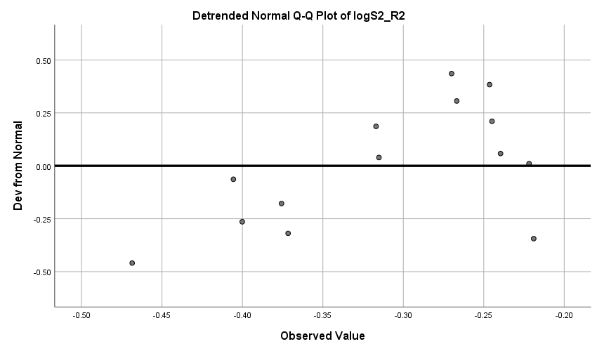

T-TEST PAIRS=logS1_R1 logS2_R1 logS1_R2 WITH logS1_R2 logS2_R2 logS2_R2 (PAIRED)  
/CRITERIA=CI(.9500)  
/MISSING=ANALYSIS.

# **T-Test**

NotesNotes, table, 0 levels of column headers and 2 levels of row headers, table with 3 columns and 14 rows

| Output Created |  | 15-APR-2019 23:52:36 |
| --- | --- | --- |
| Comments |  |  |
| Input | Data | Z:\Documents\GitHub\STISIM-Task-Analysis\SPSS Results\Driving mean speed.sav |
|  | Active Dataset | DataSet1 |
|  | Filter | <none> |
|  | Weight | <none> |
|  | Split File | <none> |
|  | N of Rows in Working Data File | 14 |
| Missing Value Handling | Definition of Missing | User defined missing values are treated as missing. |
|  | Cases Used | Statistics for each analysis are based on the cases with no missing or out-of-range data for any variable in the analysis. |
| Syntax |  | T-TEST PAIRS=logS1_R1 logS2_R1 logS1_R2 WITH logS1_R2 logS2_R2 logS2_R2 (PAIRED) /CRITERIA=CI(.9500) /MISSING=ANALYSIS. |
| Resources | Processor Time | 00:00:00.00 |
|  | Elapsed Time | 00:00:00.01 |

Paired Samples StatisticsPaired Samples Statistics, table, 1 levels of column headers and 2 levels of row headers, table with 6 columns and 8 rows

|  |  | Mean | N | Std. Deviation | Std. Error Mean |
| --- | --- | --- | --- | --- | --- |
| Pair 1 | logS1_R1 | -.3172 | 14 | .06915 | .01848 |
|  | logS1_R2 | -.3102 | 14 | .07380 | .01972 |
| Pair 2 | logS2_R1 | -.3304 | 14 | .07098 | .01897 |
|  | logS2_R2 | -.3116 | 14 | .08005 | .02139 |
| Pair 3 | logS1_R2 | -.3102 | 14 | .07380 | .01972 |
|  | logS2_R2 | -.3116 | 14 | .08005 | .02139 |

Paired Samples CorrelationsPaired Samples Correlations, table, 1 levels of column headers and 2 levels of row headers, table with 5 columns and 5 rows

|  |  | N | Correlation | Sig. |
| --- | --- | --- | --- | --- |
| Pair 1 | logS1_R1 & logS1_R2 | 14 | .926 | .000 |
| Pair 2 | logS2_R1 & logS2_R2 | 14 | .878 | .000 |
| Pair 3 | logS1_R2 & logS2_R2 | 14 | .754 | .002 |

Paired Samples TestPaired Samples Test, table, 3 levels of column headers and 2 levels of row headers, table with 10 columns and 7 rows

[output not shown]

*Nonparametric Tests: Related Samples.  
NPTESTS  
/RELATED TEST(S1_R1 S1_R2) WILCOXON  
/MISSING SCOPE=ANALYSIS USERMISSING=EXCLUDE  
/CRITERIA ALPHA=0.05 CILEVEL=95.

# **Nonparametric Tests**

NotesNotes, table, 0 levels of column headers and 2 levels of row headers, table with 3 columns and 12 rows

| Output Created |  | 15-APR-2019 23:52:36 |
| --- | --- | --- |
| Comments |  |  |
| Input | Data | Z:\Documents\GitHub\STISIM-Task-Analysis\SPSS Results\Driving mean speed.sav |
|  | Active Dataset | DataSet1 |
|  | Filter | <none> |
|  | Weight | <none> |
|  | Split File | <none> |
|  | N of Rows in Working Data File | 14 |
| Syntax |  | NPTESTS /RELATED TEST(S1_R1 S1_R2) WILCOXON /MISSING SCOPE=ANALYSIS USERMISSING=EXCLUDE /CRITERIA ALPHA=0.05 CILEVEL=95. |
| Resources | Processor Time | 00:00:00.14 |
|  | Elapsed Time | 00:00:00.09 |

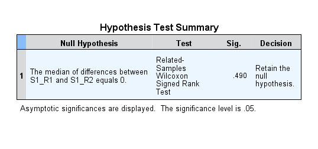

*Nonparametric Tests: Related Samples.  
NPTESTS  
/RELATED TEST(S2_R1 S2_R2) WILCOXON  
/MISSING SCOPE=ANALYSIS USERMISSING=EXCLUDE  
/CRITERIA ALPHA=0.05 CILEVEL=95.

# **Nonparametric Tests**

NotesNotes, table, 0 levels of column headers and 2 levels of row headers, table with 3 columns and 12 rows

| Output Created |  | 15-APR-2019 23:52:36 |
| --- | --- | --- |
| Comments |  |  |
| Input | Data | Z:\Documents\GitHub\STISIM-Task-Analysis\SPSS Results\Driving mean speed.sav |
|  | Active Dataset | DataSet1 |
|  | Filter | <none> |
|  | Weight | <none> |
|  | Split File | <none> |
|  | N of Rows in Working Data File | 14 |
| Syntax |  | NPTESTS /RELATED TEST(S2_R1 S2_R2) WILCOXON /MISSING SCOPE=ANALYSIS USERMISSING=EXCLUDE /CRITERIA ALPHA=0.05 CILEVEL=95. |
| Resources | Processor Time | 00:00:00.20 |
|  | Elapsed Time | 00:00:00.10 |

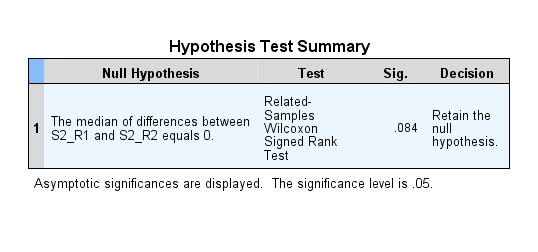

*Nonparametric Tests: Related Samples.  
NPTESTS  
/RELATED TEST(S1_R2 S2_R2) WILCOXON  
/MISSING SCOPE=ANALYSIS USERMISSING=EXCLUDE  
/CRITERIA ALPHA=0.05 CILEVEL=95.

# **Nonparametric Tests**

NotesNotes, table, 0 levels of column headers and 2 levels of row headers, table with 3 columns and 12 rows

| Output Created |  | 15-APR-2019 23:52:36 |
| --- | --- | --- |
| Comments |  |  |
| Input | Data | Z:\Documents\GitHub\STISIM-Task-Analysis\SPSS Results\Driving mean speed.sav |
|  | Active Dataset | DataSet1 |
|  | Filter | <none> |
|  | Weight | <none> |
|  | Split File | <none> |
|  | N of Rows in Working Data File | 14 |
| Syntax |  | NPTESTS /RELATED TEST(S1_R2 S2_R2) WILCOXON /MISSING SCOPE=ANALYSIS USERMISSING=EXCLUDE /CRITERIA ALPHA=0.05 CILEVEL=95. |
| Resources | Processor Time | 00:00:00.16 |
|  | Elapsed Time | 00:00:00.10 |

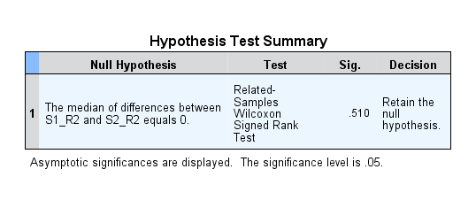